## Example Summary

In this example you will learn how to setup multi-mode radio driver to send data to a receiver. The Dual Mode TX example configures a BLE and proprietary radio mode to transmit the same random packet. The packet is first transmitted using the proprietary radio driver, then the same packet is then transmitted 500 ms later using the BLE radio driver. This example is meant to be used with the Dual Mode RX example or Smart RF Studio. For every proprietary packet sent Board_PIN_LED2 is turned on and Board_PIN_LED1 is turned off. When the same BLE packet is sent, Board_PIN_LED2 is turned off and Board_PIN_LED1 is turned on. The frequency and other RF settings can be modified using SmartRF Studio.

## Peripherals Exercised

- `Board_PIN_LED2` - Blinking indicates a successful transmission of the proprietary packet (500 ms)
- `Board_PIN_LED1` - Blinking indicates a successful transmission of the BLE packet (500 ms)

## Resources & Jumper Settings

> If you’re using an IDE (such as CCS or IAR), please refer to Board.html in your project directory for resources used and board-specific jumper settings. Otherwise, you can find Board.html in the directory <SDK_INSTALL_DIR>/source/ti/boards/<BOARD>.

## Example Usage

The use of this example will require two launchpads, one running rfDualModeTx (`Board_1`) and another running rfDualModeRx (`Board_2`). Run Board_2 first, followed by Board_1. Board_1 is set to alternate between transmitting a proprietary packet and BLE packet every 500 ms. Board_PIN_LED2 on Board_1 will turn on when a proprietary packet is transmitted. Board_PIN_LED2 on Board_2 will turn on to indicate the packet was successfully received. On Board_1, Board_PIN_LED2 will turn off and Board_PIN_LED1 will turn on to indicate the BLE packet was successfully sent. The behavior on Board_2 will mimic the LEDs on Board_1 with Board_PIN_LED2 turning off and Board_PIN_LED1 turning on. This indicates the BLE packet was successfully received and matches the proprietary packet. The cycle will then restart with the new packet.

If a packet is missed from the receiver, the current status of the lights will remain. The extended duration that the LED is on ( > 500 ms) indicates that the receiver is stuck in its previous state (see figure 1). The next proprietary will cause the receiver and transmitter to resync.

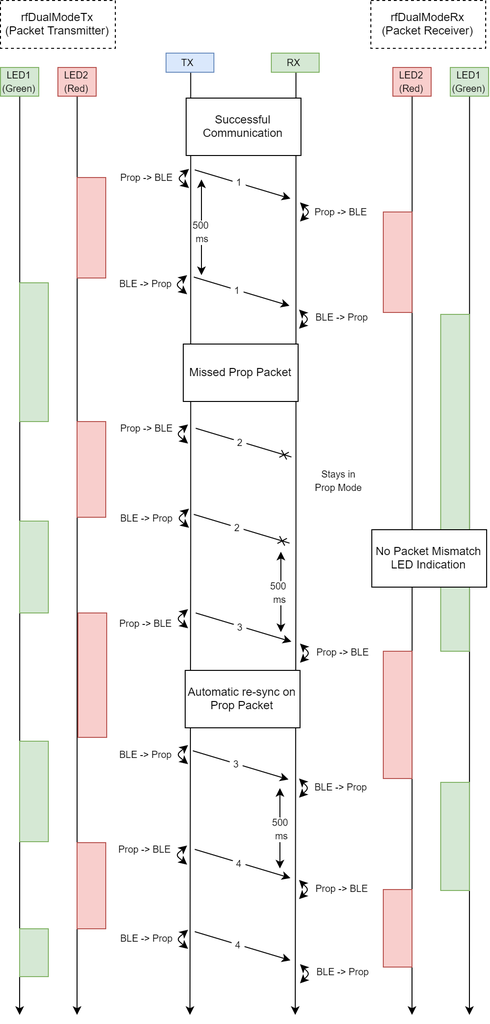

If the BLE packet is received, but the packet is not the same as the proprietary packet both Board_PIN_LED1 and Board_PIN_LED2 will turn on (see figure 2). This means both a proprietary packet and BLE packet were received but interference or a missed packet has caused the transmitter and receiver to become out of sync. If this happens the receiver and transmitter will automatically resync with the next proprietary packet.

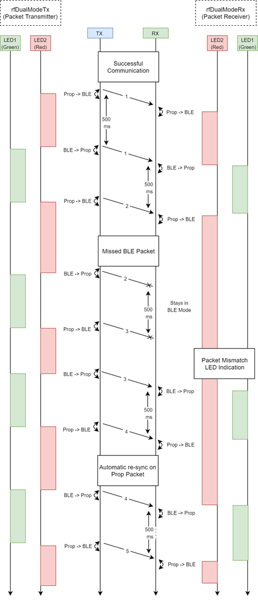

Note for IAR users: When using the CC1310DK, the TI XDS110v3 USB Emulator must be selected. For the CC1310_LAUNCHXL, select TI XDS110 Emulator. In both cases, select the cJTAG interface.